# Data Visualization

### Aesthetics

These are the aesthetics you can consider within aes() in this chapter: x, y, color, fill, size, alpha, labels and shape.

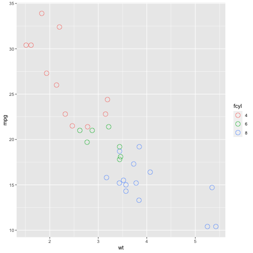

```r
# Change cyl inside mtcars to a factor
#mtcars$fcyl <- as.factor(mtcars$cyl)

# Change shape and size of the points in the above plot
ggplot(mtcars, aes(x = wt, y = mpg, col = fcyl)) +
  geom_point(shape = 1, size = 4)
```

### Aesthetics

These are the aesthetics you can consider within aes() in this chapter: x, y, color, fill, size, alpha, labels and shape.

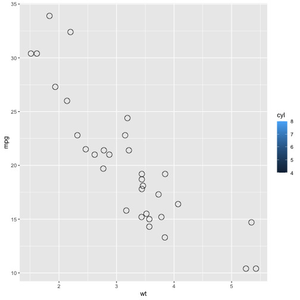

```r
# 1 - Map cyl to fill
ggplot(mtcars, aes(x = wt, y = mpg, fill = cyl)) +
  geom_point(shape = 1, size = 4)
```

### Aesthetics

These are the aesthetics you can consider within aes() in this chapter: x, y, color, fill, size, alpha, labels and shape.

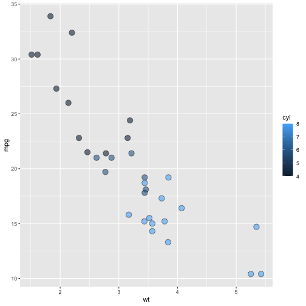

```r
# 2 - Change shape and alpha of the points in the above plot
ggplot(mtcars, aes(x = wt, y = mpg, fill = cyl)) +
  geom_point(shape = 21, size = 4, alpha = 0.6)
```

### Aesthetics

These are the aesthetics you can consider within aes() in this chapter: x, y, color, fill, size, alpha, labels and shape.

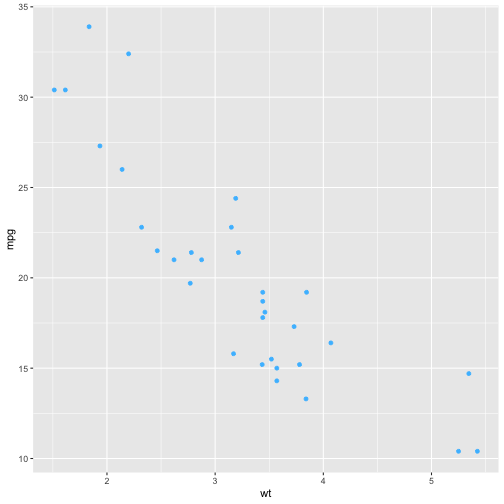

```r
# library(RColorBrewer)

# Define a hexadecimal color
my_color <- "#4ABEFF"

# Set the color aesthetic and attribute
ggplot(mtcars, aes(x = wt, y = mpg, color = cyl)) +
  geom_point(color = my_color)
```

### Aesthetics

These are the aesthetics you can consider within aes() in this chapter: x, y, color, fill, size, alpha, labels and shape.

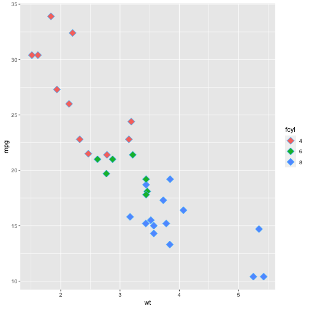

```r
# Set the fill aesthetic and color, size and shape attributes
ggplot(mtcars, aes(x = wt, y = mpg, fill = fcyl)) +
  geom_point(size = 4, shape = 23, color = my_color)
```

### Aesthetics

These are the aesthetics you can consider within aes() in this chapter: x, y, color, fill, size, alpha, labels and shape.

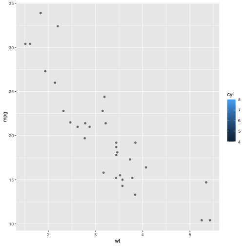

```r
# Expand to draw points with alpha 0.5
ggplot(mtcars, aes(x = wt, y = mpg, fill = cyl)) +
  geom_point(alpha = 0.5)
```

### Aesthetics

These are the aesthetics you can consider within aes() in this chapter: x, y, color, fill, size, alpha, labels and shape.

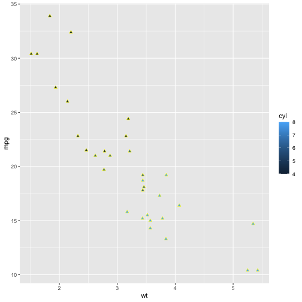

```r
# Expand to draw points with shape 24 and color yellow
ggplot(mtcars, aes(x = wt, y = mpg, fill = cyl)) +
  geom_point(shape = 24, color = 'yellow')
```

### Aesthetics

These are the aesthetics you can consider within aes() in this chapter: x, y, color, fill, size, alpha, labels and shape.

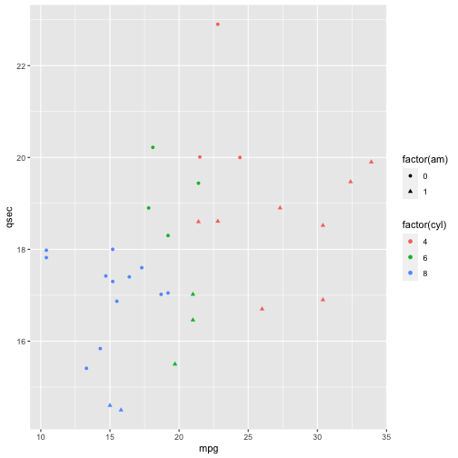

```r
# Add mapping: factor(am) onto shape (now 4 aesthetics):
ggplot(mtcars,
       aes(x = mpg, y = qsec, col = factor(cyl), shape = factor(am))) +
  geom_point()
```

### Histograms

Histograms are one of the most common and intuitive ways of showing distributions.

```r
# Print out head of mtcars
head(mtcars)
```

```
                   mpg cyl disp  hp drat    wt  qsec vs am gear carb fcyl
Mazda RX4         21.0   6  160 110 3.90 2.620 16.46  0  1    4    4    6
Mazda RX4 Wag     21.0   6  160 110 3.90 2.875 17.02  0  1    4    4    6
Datsun 710        22.8   4  108  93 3.85 2.320 18.61  1  1    4    1    4
Hornet 4 Drive    21.4   6  258 110 3.08 3.215 19.44  1  0    3    1    6
Hornet Sportabout 18.7   8  360 175 3.15 3.440 17.02  0  0    3    2    8
Valiant           18.1   6  225 105 2.76 3.460 20.22  1  0    3    1    6
```

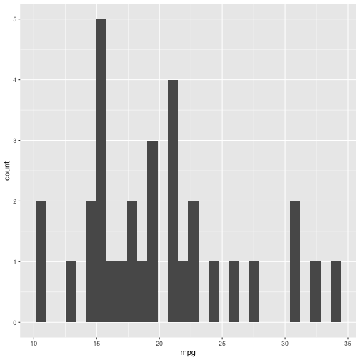

```r
# 1 - Make a univariate histogram
ggplot(mtcars, aes(mpg)) +
  geom_histogram()
```

### Histograms

Histograms are one of the most common and intuitive ways of showing distributions.

```r
# Print out head of mtcars
head(mtcars)
```

```
                   mpg cyl disp  hp drat    wt  qsec vs am gear carb fcyl
Mazda RX4         21.0   6  160 110 3.90 2.620 16.46  0  1    4    4    6
Mazda RX4 Wag     21.0   6  160 110 3.90 2.875 17.02  0  1    4    4    6
Datsun 710        22.8   4  108  93 3.85 2.320 18.61  1  1    4    1    4
Hornet 4 Drive    21.4   6  258 110 3.08 3.215 19.44  1  0    3    1    6
Hornet Sportabout 18.7   8  360 175 3.15 3.440 17.02  0  0    3    2    8
Valiant           18.1   6  225 105 2.76 3.460 20.22  1  0    3    1    6
```

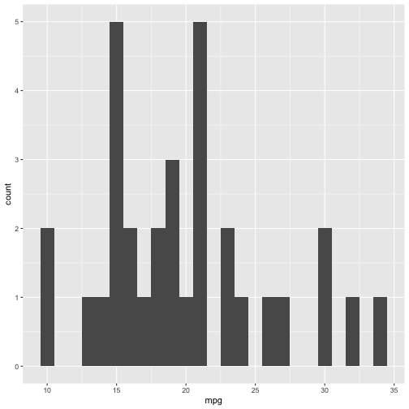

```r
# 2 - Plot 1, plus set binwidth to 1 in the geom layer
ggplot(mtcars, aes(mpg)) +
  geom_histogram(binwidth = 1)
```

### Histograms

Histograms are one of the most common and intuitive ways of showing distributions.

```r
# Print out head of mtcars
head(mtcars)
```

```
                   mpg cyl disp  hp drat    wt  qsec vs am gear carb fcyl
Mazda RX4         21.0   6  160 110 3.90 2.620 16.46  0  1    4    4    6
Mazda RX4 Wag     21.0   6  160 110 3.90 2.875 17.02  0  1    4    4    6
Datsun 710        22.8   4  108  93 3.85 2.320 18.61  1  1    4    1    4
Hornet 4 Drive    21.4   6  258 110 3.08 3.215 19.44  1  0    3    1    6
Hornet Sportabout 18.7   8  360 175 3.15 3.440 17.02  0  0    3    2    8
Valiant           18.1   6  225 105 2.76 3.460 20.22  1  0    3    1    6
```

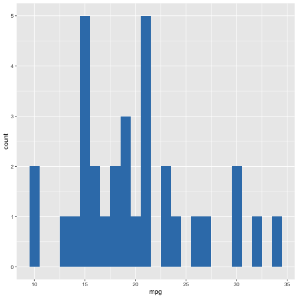

```r
# 4 - plot 3, plus SET the fill attribute to "#377EB8"
ggplot(mtcars, aes(mpg)) +
  geom_histogram(binwidth = 1, fill = "#377EB8")
```

### Bar

geom_bar() makes the height of the bar proportional to the number of cases in each group

```r
# Print out head of mtcars
head(mtcars)
```

```
                   mpg cyl disp  hp drat    wt  qsec vs am gear carb fcyl
Mazda RX4         21.0   6  160 110 3.90 2.620 16.46  0  1    4    4    6
Mazda RX4 Wag     21.0   6  160 110 3.90 2.875 17.02  0  1    4    4    6
Datsun 710        22.8   4  108  93 3.85 2.320 18.61  1  1    4    1    4
Hornet 4 Drive    21.4   6  258 110 3.08 3.215 19.44  1  0    3    1    6
Hornet Sportabout 18.7   8  360 175 3.15 3.440 17.02  0  0    3    2    8
Valiant           18.1   6  225 105 2.76 3.460 20.22  1  0    3    1    6
```

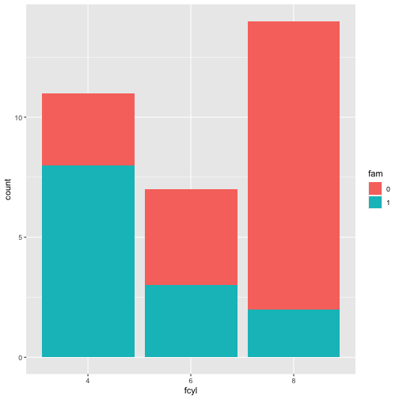

```r
# Change cyl inside mtcars to a factor
mtcars$fcyl <- as.factor(mtcars$cyl)

# Change cyl inside mtcars to a factor
mtcars$fam <- as.factor(mtcars$am)

# Draw a bar plot of cyl, filled according to am
ggplot(mtcars, aes(x = fcyl, fill = fam)) +
  geom_bar()
```

### Bar

dodge: place the bars next to each other.

```r
# Print out head of mtcars
head(mtcars)
```

```
                   mpg cyl disp  hp drat    wt  qsec vs am gear carb fcyl fam
Mazda RX4         21.0   6  160 110 3.90 2.620 16.46  0  1    4    4    6   1
Mazda RX4 Wag     21.0   6  160 110 3.90 2.875 17.02  0  1    4    4    6   1
Datsun 710        22.8   4  108  93 3.85 2.320 18.61  1  1    4    1    4   1
Hornet 4 Drive    21.4   6  258 110 3.08 3.215 19.44  1  0    3    1    6   0
Hornet Sportabout 18.7   8  360 175 3.15 3.440 17.02  0  0    3    2    8   0
Valiant           18.1   6  225 105 2.76 3.460 20.22  1  0    3    1    6   0
```

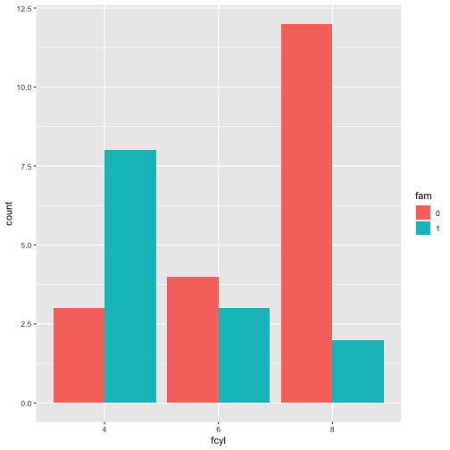

```r
# Change the position argument to "dodge""
ggplot(mtcars, aes(x = fcyl, fill = fam)) +
  geom_bar(position = "dodge")
```

### Bar

Overlapping bar plots

```r
# Print out head of mtcars
head(mtcars)
```

```
                   mpg cyl disp  hp drat    wt  qsec vs am gear carb fcyl fam
Mazda RX4         21.0   6  160 110 3.90 2.620 16.46  0  1    4    4    6   1
Mazda RX4 Wag     21.0   6  160 110 3.90 2.875 17.02  0  1    4    4    6   1
Datsun 710        22.8   4  108  93 3.85 2.320 18.61  1  1    4    1    4   1
Hornet 4 Drive    21.4   6  258 110 3.08 3.215 19.44  1  0    3    1    6   0
Hornet Sportabout 18.7   8  360 175 3.15 3.440 17.02  0  0    3    2    8   0
Valiant           18.1   6  225 105 2.76 3.460 20.22  1  0    3    1    6   0
```

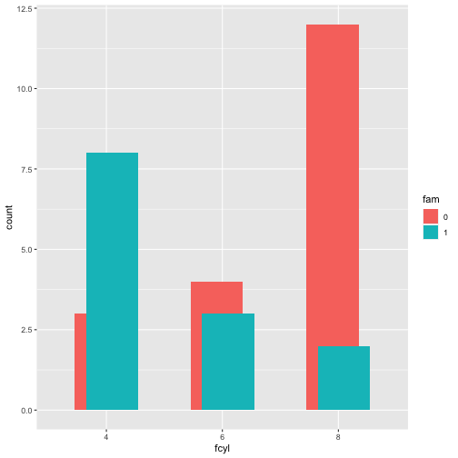

```r
# 2 - Define posn_d with position_dodge()
posn_d <- position_dodge(0.2)

# 3 - Change the position argument to posn_d
ggplot(mtcars, aes(x = fcyl, fill = fam)) +
  geom_bar(position = posn_d)
```

### Bar

Overlapping bar plots

```r
# Print out head of mtcars
head(mtcars)
```

```
                   mpg cyl disp  hp drat    wt  qsec vs am gear carb fcyl fam
Mazda RX4         21.0   6  160 110 3.90 2.620 16.46  0  1    4    4    6   1
Mazda RX4 Wag     21.0   6  160 110 3.90 2.875 17.02  0  1    4    4    6   1
Datsun 710        22.8   4  108  93 3.85 2.320 18.61  1  1    4    1    4   1
Hornet 4 Drive    21.4   6  258 110 3.08 3.215 19.44  1  0    3    1    6   0
Hornet Sportabout 18.7   8  360 175 3.15 3.440 17.02  0  0    3    2    8   0
Valiant           18.1   6  225 105 2.76 3.460 20.22  1  0    3    1    6   0
```

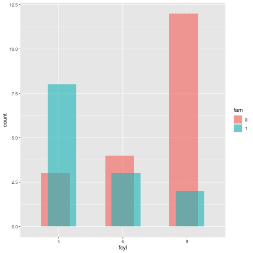

```r
# 2 - Define posn_d with position_dodge()
posn_d <- position_dodge(0.2)

# 4 - Use posn_d as position and adjust alpha to 0.6
ggplot(mtcars, aes(x = fcyl, fill = fam)) +
  geom_bar(position = posn_d, alpha = 0.6)
```

### Bar

Colors

```r
# Print out head of mtcars
head(mtcars)
```

```
                   mpg cyl disp  hp drat    wt  qsec vs am gear carb fcyl fam
Mazda RX4         21.0   6  160 110 3.90 2.620 16.46  0  1    4    4    6   1
Mazda RX4 Wag     21.0   6  160 110 3.90 2.875 17.02  0  1    4    4    6   1
Datsun 710        22.8   4  108  93 3.85 2.320 18.61  1  1    4    1    4   1
Hornet 4 Drive    21.4   6  258 110 3.08 3.215 19.44  1  0    3    1    6   0
Hornet Sportabout 18.7   8  360 175 3.15 3.440 17.02  0  0    3    2    8   0
Valiant           18.1   6  225 105 2.76 3.460 20.22  1  0    3    1    6   0
```

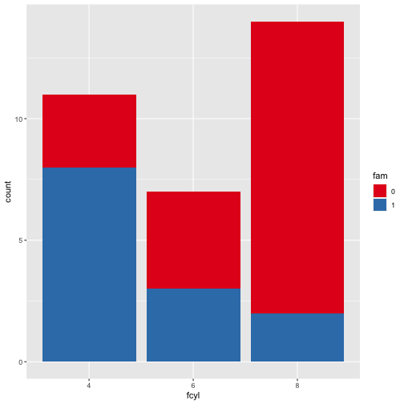

```r
# Example of how to use a brewed color palette
ggplot(mtcars, aes(x = fcyl, fill = fam)) +
  geom_bar() +
  scale_fill_brewer(palette = "Set1")
```

### Line plots

These are the aesthetics you can consider within aes() in this chapter: x, y, color, fill, size, alpha, labels and shape.

```r
# Print out head of economics
head(economics)
```

```
# A tibble: 6 × 6
  date         pce    pop psavert uempmed unemploy
  <date>     <dbl>  <dbl>   <dbl>   <dbl>    <dbl>
1 1967-07-01  507. 198712    12.6     4.5     2944
2 1967-08-01  510. 198911    12.6     4.7     2945
3 1967-09-01  516. 199113    11.9     4.6     2958
4 1967-10-01  512. 199311    12.9     4.9     3143
5 1967-11-01  517. 199498    12.8     4.7     3066
6 1967-12-01  525. 199657    11.8     4.8     3018
```

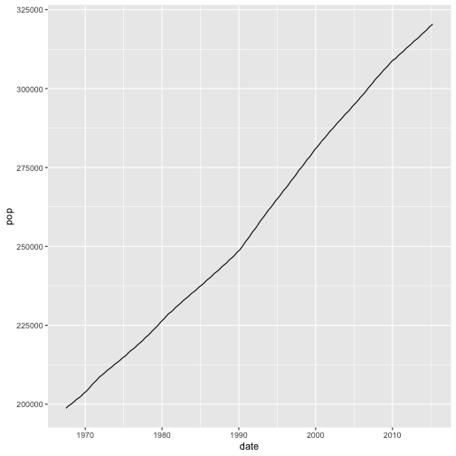

```r
# Basic line plot
ggplot(data=economics, aes(x=date, y=pop))+
  geom_line()
```

### Line plots

These are the aesthetics you can consider within aes() in this chapter: x, y, color, fill, size, alpha, labels and shape.

```r
# Print out head of economics
head(economics)
```

```
# A tibble: 6 × 6
  date         pce    pop psavert uempmed unemploy
  <date>     <dbl>  <dbl>   <dbl>   <dbl>    <dbl>
1 1967-07-01  507. 198712    12.6     4.5     2944
2 1967-08-01  510. 198911    12.6     4.7     2945
3 1967-09-01  516. 199113    11.9     4.6     2958
4 1967-10-01  512. 199311    12.9     4.9     3143
5 1967-11-01  517. 199498    12.8     4.7     3066
6 1967-12-01  525. 199657    11.8     4.8     3018
```

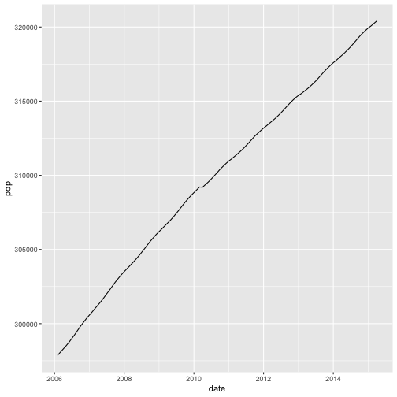

```r
# Plot a subset of the data
ggplot(data=subset(economics, date > as.Date("2006-1-1")),
       aes(x=date, y=pop))+geom_line()
```

### Line plots

These are the aesthetics you can consider within aes() in this chapter: x, y, color, fill, size, alpha, labels and shape.

```r
# Print out head of economics
head(economics)
```

```
# A tibble: 6 × 6
  date         pce    pop psavert uempmed unemploy
  <date>     <dbl>  <dbl>   <dbl>   <dbl>    <dbl>
1 1967-07-01  507. 198712    12.6     4.5     2944
2 1967-08-01  510. 198911    12.6     4.7     2945
3 1967-09-01  516. 199113    11.9     4.6     2958
4 1967-10-01  512. 199311    12.9     4.9     3143
5 1967-11-01  517. 199498    12.8     4.7     3066
6 1967-12-01  525. 199657    11.8     4.8     3018
```

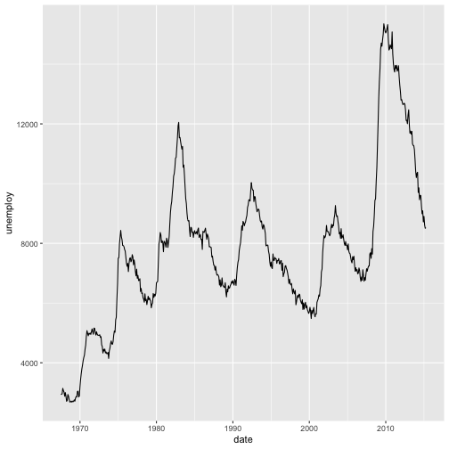

```r
# Plot unemploy as a function of date using a line plot
ggplot(economics, aes(x = date, y = unemploy)) +
  geom_line()
```

### Line plots

These are the aesthetics you can consider within aes() in this chapter: x, y, color, fill, size, alpha, labels and shape.

```r
# Print out head of Orange
head(Orange)
```

```
  Tree  age circumference
1    1  118            30
2    1  484            58
3    1  664            87
4    1 1004           115
5    1 1231           120
6    1 1372           142
```

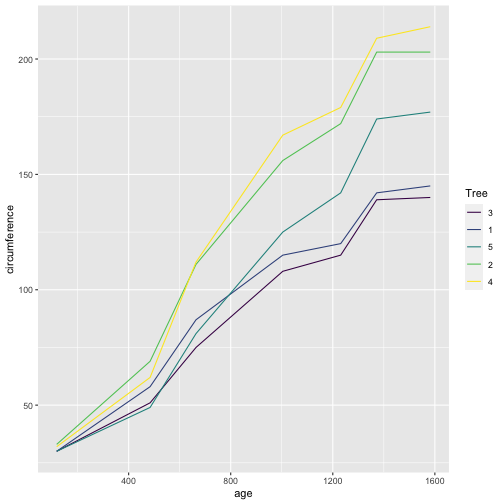

```r
ggplot(Orange) +
  geom_line(aes(x = age, y = circumference, colour = Tree))
```

### Line plots

These are the aesthetics you can consider within aes() in this chapter: x, y, color, fill, size, alpha, labels and shape.

```r
# Print out head of Orange
head(Orange)
```

```
  Tree  age circumference
1    1  118            30
2    1  484            58
3    1  664            87
4    1 1004           115
5    1 1231           120
6    1 1372           142
```

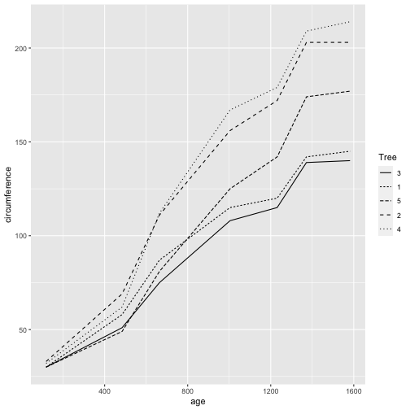

```r
ggplot(Orange) +
  geom_line(aes(x = age, y = circumference, linetype = Tree))
```